# ΕΙΣΑΓΩΓΙΚΗ ΣΤΑΤΙΣΤΙΚΗ ΜΕ PYTHON

# Ι. Οι Βασικές Μονομεταβλητές Στατιστικές

0. Δεδομένα και Διαγράμματα

- 0.1 Λίστες Τυχαίων Αριθμών
- 0.2 Εισαγωγή Δεδομένων από Αρχείο
- 0.3 Κατασκευή Σχεδιαγραμμάτων στο matplotlib

1. Βασικές Μονομεταβλητές Στατιστικές

- 1.1 Μέση Τιμή
- 1.2 Ενδιάμεση Τιμή
- 1.3 Εκατοστημόρια
- 1.4 Επικρατέστερες Τιμές
- 1.5 Εύρος, Μεγαλύτερες-Μικρότερες Τιμές
- 1.6 Διακύμανση και Τυπική Απόκλιση
- 1.7 Συγκεντρωτικές Μονομεταβλητές Στατιστικές

2. Σχεδιαγράμματα Μονομεταβλητών Στατιστικών

- 2.1 Απλά Σχεδιαγράμματα
- 2.2 Ραβδογράμματα
- 2.3 Κυκλικά Διαγράμματα
- 2.4 Ιστογράμματα
- 2.5 Θηκογράμματα

### Το επόμενο κελί περιέχει όλα τα μόντουλ που χρειάζονται να εισαχθούν στη συνέχεια και ΠΡΕΠΕΙ ΝΑ ΕΚΤΑΛΕΣΘΕΙ ΑΠΟ ΤΗΝ ΑΡΧΗ.

```python
import math
import random
import csv
import urllib2
from collections import Counter
import numpy as np
import pandas as pd
from scipy import stats, integrate
import seaborn as sns       # pip install seaborn
sns.set_style("white")      # For seaborn to show axes in iPython Notebook
import matplotlib.pyplot as plt
from matplotlib import cm

# For printing plots in iPython Notebook cells
%matplotlib inline
```

# 0. ΔΕΔΟΜΕΝΑ ΚΑΙ ΔΙΑΓΡΑΜΜΑΤΑ

## 0.1 Λίστες Τυχαίων Αριθμών

```python
dl = []
dl.append(8)
dl.append(2)
dl.append(3.3)
dl.extend([4,7])
dl
len(dl)
dl[3] = 3.3
len(dl)
```

```
5
```

#### 1. Δημιουργία λίστας πραγματικών αριθμών στο διάστημα [0, 1) με random.random

```python
x = random.random()
x
```

```
0.127169513695087
```

```python
rlist1 = [random.random() for _ in range(10)]
print rlist1
rlist1 = [float(int(a*1e3))*1e-3 for a in rlist1]
print rlist1
```

```
[0.005716612885187433, 0.5823060967149217, 0.19848229153293762, 0.7889160676080422, 0.34834358621539396, 0.5822478884747723, 0.9427342139640102, 0.12638856743610216, 0.6013304781751084, 0.5987000627918575]
[0.005, 0.582, 0.198, 0.788, 0.34800000000000003, 0.582, 0.9420000000000001, 0.126, 0.601, 0.598]
```

```python
print int(1e5), float(1e-3), type(1e5), type(1e-5)
```

```
100000 0.001 <type 'float'> <type 'float'>
```

#### 2. Δημιουργία λίστας πραγματικών αριθμών στο διάστημα [a, b] με random.uniform

```python
x = random.uniform(2,10)
x
```

```
3.4226932159641033
```

```python
rlist1u = [random.uniform(-5,10) for _ in range(10)]
print rlist1u
rlist1u = [float(int(a*1e3))*1e-3 for a in rlist1u]
print rlist1u
```

```
[-2.8355527908053526, -2.334489399015725, 5.626256693062642, -3.8025880599804345, 4.915505897886275, 8.983881870088418, 8.753997450440057, -3.394018575388899, 4.942655056141762, -2.3434394868415453]
[-2.835, -2.334, 5.626, -3.802, 4.915, 8.983, 8.753, -3.394, 4.942, -2.343]
```

#### 3. Δημιουργία λίστας πραγματικών αριθμών με random.normalvariate(mean, sdev) μέσω της κανονικής κατανομής με μέση τιμή mean και τυπική απόκλιση sdev

```python
x = random.normalvariate(-1,0.8)
x
```

```
-0.5667649453139094
```

```python
rlist1n = [random.normalvariate(-1,0.8) for _ in range(10)]
print rlist1n
rlist1n = [float(int(a*1e3))*1e-3 for a in rlist1n]
print rlist1n
```

```
[-0.5393683668962395, 0.4486183278282345, -1.7510048414320036, -1.060879747185659, -1.5944219405169644, -0.876415906459292, -0.9844575320787582, -1.8666059590553146, -0.1784178546088494, -0.3941028195222135]
[-0.539, 0.448, -1.7510000000000001, -1.06, -1.594, -0.876, -0.984, -1.866, -0.178, -0.394]
```

#### 4. Δημιουργία λίστας ακέραιων με random.randrange

```python
rl1 = range(10,21,4)
print rl1
n = random.randrange(10,21)
n
```

```
[10, 14, 18]
```

```
12
```

```python
rlist2 = [random.randrange(10) for _ in range(4)]
print rlist2
rlist3 = [random.randrange(30,50) for _ in range(8)]
print rlist3
rlist4 = [random.randrange(30,50,3) for _ in range(15)]
print rlist4
```

```
[8, 1, 2, 4]
[35, 31, 37, 47, 30, 32, 49, 31]
[42, 45, 42, 36, 42, 30, 45, 48, 42, 45, 42, 30, 39, 39, 30]
```

#### 5. Δημιουργία λίστας με random.shuffle

```python
r10 = range(10)
print r10
random.shuffle(r10) #range(10))
print r10
list1 = [random.random() for _ in range(10)]
random.shuffle(list1)
print list1
list1 = [float(int(a*1e3))*1e-3 for a in list1]
print list1
```

```
[0, 1, 2, 3, 4, 5, 6, 7, 8, 9]
[5, 7, 1, 9, 0, 8, 6, 3, 4, 2]
[0.8775862901766075, 0.21798621406615315, 0.8317574439231071, 0.4665547083623053, 0.5810705017827348, 0.42563822239543014, 0.015477145306547535, 0.8525068968107637, 0.9401870065432959, 0.33083121506996804]
[0.877, 0.217, 0.8310000000000001, 0.466, 0.581, 0.425, 0.015, 0.852, 0.9400000000000001, 0.33]
```

#### 6. Δημιουργία λίστας με random.choice

```python
r20 = range(20)
print r20
a = random.choice(r20)
a
```

```
[0, 1, 2, 3, 4, 5, 6, 7, 8, 9, 10, 11, 12, 13, 14, 15, 16, 17, 18, 19]
```

```
18
```

```python
rlist5 = [random.choice(range(10)) for _ in range(10)]
print rlist5, len(rlist5)
rlist6 = [random.choice(list1) for _ in range(10)]
print rlist6
```

```
[1, 6, 1, 4, 5, 7, 1, 8, 8, 5] 10
[0.581, 0.425, 0.466, 0.581, 0.33, 0.33, 0.425, 0.466, 0.581, 0.217]
```

#### 7. Δημιουργία λίστας με random.sample (χωρίς επαναλήψεις)

```python
rlist7 = random.sample(range(60),10)
print rlist7
```

```
[25, 48, 58, 33, 20, 11, 38, 49, 10, 47]
```

## 0.2 Εισαγωγή Δεδομένων από Αρχείο

#### Δεδομένα από τοπικό αρχείο

```python
f = open('names-freqs.csv','r')
print f.readline()
print f.readline()
print f.readline()
list_names_freqs = f.readlines()
print list_names_freqs
```

```
Timothy,1

Baron,6

Homburg,1

['Ivanovitch,4\n', 'Lovell,1\n', 'Astley,38\n', 'Alexandrovna,2\n', 'Nadia,3\n', 'Mischa,2\n', 'Nicolai,1\n', 'Martha,8\n', 'Monsieur,3\n', 'Hortense,1\n', 'Therese,1\n', 'Vassilievna,1\n', 'Marquise,1\n', 'Albert,2\n', 'Potapitch,13\n', 'Baroness,9\n', 'Gretchen,2\n', 'Lisette,1\n', 'Philipovna,4\n…
```

```python
names = []
freqs = []
with open('names-freqs.csv') as f:
    reader = csv.reader(f)
    next(reader)
    for row in reader:
        names.append(str(row[0]))
        freqs.append(int(row[1]))
print names
print freqs
```

```
['Baron', 'Homburg', 'Ivanovitch', 'Lovell', 'Astley', 'Alexandrovna', 'Nadia', 'Mischa', 'Nicolai', 'Martha', 'Monsieur', 'Hortense', 'Therese', 'Vassilievna', 'Marquise', 'Albert', 'Potapitch', 'Baroness', 'Gretchen', 'Lisette', 'Philipovna', 'Maria', 'Petrovitch', 'Marquis', 'Mademoiselle', 'Alex…
[6, 1, 4, 1, 38, 2, 3, 2, 1, 8, 3, 1, 1, 1, 1, 2, 13, 9, 2, 1, 4, 6, 1, 7, 1, 22, 2, 2, 44, 1, 6, 1, 1, 1, 1, 81, 1, 1, 1, 27, 1, 1, 2]
```

```python
with open('hashtags-dates_n.csv', 'r') as f:
    lines=f.readlines()
    lines=lines[0].split("\\n")
    for line in lines:
        print line
```

```
7-Nov-15,15-Nov-15,22-Nov-15,29-Nov-15,6-Dec-15,13-Dec-15,20-Dec-15,27-Dec-15,3-Jan-16
refugeeconvoy,231,260,275,284,290,295,296,298,300
refugeecrisis,84322,124904,163352,186157,204363,221863,235107,244731,252250
refugeemarch,2,6,6,148,149,149,151,151,151
refugees,132231,209627,343019,425357,475432,523799,565829,602519,627576
refugeesGR,27894,35118,40382,47627,53475,60348,65542,70427,74480
refugeeswelcome,62997,109796,270169,329168,360837,393349,420177,436757,441665
Fluechtling,7339,13316,17315,24571,28121,31851,35813,39307,41540
flykting,1565,3223,4219,5420,6379,7339,7926,8418,9077
menekult,185,288,329,395,466,543,612,677,714
muelteci,21828,51338,67872,86951,115314,131271,146647,160039,167811
refugee,419267,828147,1655449,2226792,2485401,2744975,2963631,3133352,3419267
rifugiato,412,3667,4839,5610,6030,6676,7244,7586,7927
refugie,7086,19353,27542,31503,34096,36569,39907,42711,44048
paris,0,0,1917259,2640829,3124246,3311799,3516921,3634226,3737076
parisattacks,0,0,1979327,2995823,3131640,3173138,3198119,3208478,3220218
PorteOuverte,0,0,1019674,1025397,1026028,1026288,1026526,1026662,1026742
```

```python
hashtags = []
date1 = []
date2 = []
date3 = []
date4 = []
date5 = []
date6 = []
date7 = []
date8 = []
date9 = []
with open('hashtags-dates.csv','rU') as f:
    reader = csv.reader(f)
    next(reader)
    for row in reader:
        hashtags.append(str(row[0]))
        date1.append(int(row[1]))
        date2.append(int(row[2]))
        date3.append(int(row[3]))
        date4.append(int(row[4]))
        date5.append(int(row[5]))
        date6.append(int(row[6]))
        date7.append(int(row[7]))
        date8.append(int(row[8]))
        date9.append(int(row[9]))
print hashtags
print date4
```

```
['refugeeconvoy', 'refugeecrisis', 'refugeemarch', 'refugees', 'refugeesGR', 'refugeeswelcome', 'Fluechtling', 'flykting', 'menekult', 'muelteci', 'refugee', 'rifugiato', 'refugie', 'paris', 'parisattacks', 'PorteOuverte']
[284, 186157, 148, 425357, 47627, 329168, 24571, 5420, 395, 86951, 2226792, 5610, 31503, 2640829, 2995823, 1025397]
```

#### Δημιουργία λεξικού από δυο μεταβλητές

```python
names_freqs_d = dict((str(k), v) for k, v in zip(names,freqs))
print names_freqs_d
```

```
{'Baron': 6, 'Homburg': 1, 'Ivanovitch': 4, 'Lovell': 1, 'Astley': 38, 'Alexandrovna': 2, 'Nadia': 3, 'Mischa': 2, 'Nicolai': 1, 'Martha': 8, 'Monsieur': 3, 'Hortense': 1, 'Therese': 1, 'Vassilievna': 1, 'Marquise': 1, 'Albert': 2, 'Potapitch': 13, 'Baroness': 9, 'Gretchen': 2, 'Lisette': 1, 'Philip…
```

```python
hashtags_date4_d = dict((str(k), v) for k, v in zip(hashtags,date4))
print hashtags_date4_d
```

```
{'rifugiato': 5610, 'refugeeconvoy': 284, 'paris': 2640829, 'refugeesGR': 47627, 'refugee': 2226792, 'Fluechtling': 24571, 'refugeemarch': 148, 'PorteOuverte': 1025397, 'parisattacks': 2995823, 'menekult': 395, 'muelteci': 86951, 'flykting': 5420, 'refugeeswelcome': 329168, 'refugeecrisis': 186157, …
```

#### Αναζήτηση κλειδιών από τιμές σε λεξικό

```python
search_freqs = 2
search_names = []
for name in names_freqs_d.keys():
    if names_freqs_d[name] == search_freqs:
        search_names.append(name)
print search_names
```

```
['Alexandrovna', 'Mischa', 'Albert', 'Gretchen', 'Madame', 'Burmergelm', 'Prince']
```

```python
search_h = 24571
search_names = []
for name in hashtags_date4_d.keys():
    if hashtags_date4_d[name] == search_h:
        search_names.append(name)
print search_names
```

```
['Fluechtling']
```

#### Δεδομένα από το Internet

```python
url = 'https://vincentarelbundock.github.io/Rdatasets/csv/datasets/mtcars.csv'
response = urllib2.urlopen(url)
cars = []
mpg	= []
cyl = []
disp = []
hp = []
drat = []
wt = []
qsec = []
vs = []
am = []
gear = []
carb = []
reader = csv.reader(response)
next(reader)
for row in reader:
    cars.append(str(row[0]))
    mpg.append(float(row[1]))
    cyl.append(int(row[2]))
    disp.append(float(row[3]))
    hp.append(int(row[4]))
    drat.append(float(row[5]))
    wt.append(float(row[6]))
    qsec.append(float(row[7]))
    vs.append(int(row[8]))
    am.append(int(row[9]))
    gear.append(int(row[10]))
    carb.append(int(row[11]))
print cars
print mpg
print hp
```

```
['Mazda RX4', 'Mazda RX4 Wag', 'Datsun 710', 'Hornet 4 Drive', 'Hornet Sportabout', 'Valiant', 'Duster 360', 'Merc 240D', 'Merc 230', 'Merc 280', 'Merc 280C', 'Merc 450SE', 'Merc 450SL', 'Merc 450SLC', 'Cadillac Fleetwood', 'Lincoln Continental', 'Chrysler Imperial', 'Fiat 128', 'Honda Civic', 'Toyo…
[21.0, 21.0, 22.8, 21.4, 18.7, 18.1, 14.3, 24.4, 22.8, 19.2, 17.8, 16.4, 17.3, 15.2, 10.4, 10.4, 14.7, 32.4, 30.4, 33.9, 21.5, 15.5, 15.2, 13.3, 19.2, 27.3, 26.0, 30.4, 15.8, 19.7, 15.0, 21.4]
[110, 110, 93, 110, 175, 105, 245, 62, 95, 123, 123, 180, 180, 180, 205, 215, 230, 66, 52, 65, 97, 150, 150, 245, 175, 66, 91, 113, 264, 175, 335, 109]
```

## 0.3 Κατασκευή Διαγραμμάτων στο matplotlib

Για το matplotlib:

- http://matplotlib.org/index.html
- http://matplotlib.org/api/
- http://www.scipy-lectures.org/intro/matplotlib/matplotlib.html

Για το seaborn:

- https://stanford.edu/~mwaskom/software/seaborn/index.html

Για το matplotlib-pandas:

- http://www.randalolson.com/2014/06/28/how-to-make-beautiful-data-visualizations-in-python-with-matplotlib/

### Τύποι Σημείων

```
(2.5, 10.5)
```

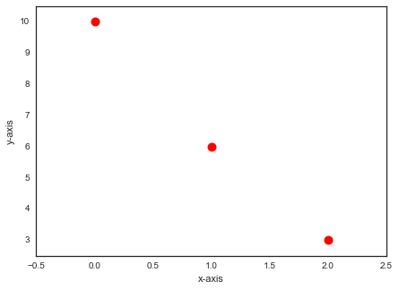

```python
#import matplotlib.pyplot as plt

plt.figure(figsize=(7, 5))
plt.plot([10,6,3],'ro',markersize=10) #,6,3]) #,'ro',markersize=20)
# plt.plot([6.5,3,8],'g*',markersize=30)
# markers = |”.” point|”,” pixel|“o” circle|“v”/“^” triangle_down/up|“<”/“>” triangle_left/right|
plt.xlabel('x-axis')
plt.ylabel('y-axis')

plt.xlim(-0.5,2.5)
plt.ylim(2.5,10.5)

# plt.show()
```

### Τύποι Ευθειών

```
(0.5, 10.5)
```

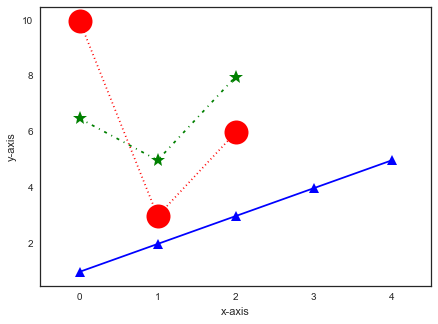

```python
# linestyle or ls | ‘solid’ | ‘dashed’, ‘dashdot’, ‘dotted’ | '-' | '--' | '-.' | ':' |

plt.figure(figsize=(7, 5))
plt.plot([10,3,6],'ro:',markersize=24)
plt.plot([6.5,5,8],'g*-.',markersize=14)
plt.plot([1,2,3,4,5],'b^-',markersize=10)
plt.xlabel('x-axis')
plt.ylabel('y-axis')
plt.xlim(-0.5,4.5)
plt.ylim(0.5,10.5)
```

### Πολλά Αντικείμενα στο Ίδιο Σχεδιάγραμμα

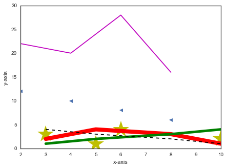

```python
plt.figure(figsize=(7, 5))
plt.plot([2,4,6,8],[22,20,28,16],'m')
plt.plot([2,4,6,8],[12,10,8,6],'<')
plt.plot([10,6,3,5],[2,4,3,1],'y*',markersize=34)
# plt.plot([3,5,6,10],[2,4,3,1],linewidth=5)
plt.plot([3,5,8,10],[2,4,3,1],'r',linewidth=8)
plt.plot([3,5,8,10],[1,2,3,4],'g',linewidth=5)
plt.plot([3,5,8,10],[4,3,2,1],'k--')
plt.xlabel('x-axis')
plt.ylabel('y-axis')
```

### Γραφικές Παραστάσεις Συναρτήσεων

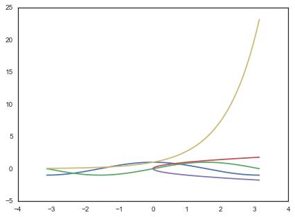

```python
plt.figure(figsize=(7, 5))
X = np.linspace(-np.pi, np.pi,10256,endpoint=True)
# X = [-math.pi,math.pi+1,0.001]
Y1, Y2, Y3, Y4, Y5 = np.cos(X), np.sin(X), np.sqrt(X), -np.sqrt(X),np.exp(X)
# Y1, Y2, Y3, Y4, Y5 = math.cos(X), math.sin(X), math.sqrt(X), -math.sqrt(X),math.exp(X)
plt.plot(X,Y1)
plt.plot(X,Y2)
plt.plot(X,Y3)
plt.plot(X,Y4)
plt.plot(X,Y5)
```

### Πολλά Αντικείμενα σε Υποσχεδιαγράμματα (subplots)

```python
from IPython.display import IFrame
IFrame('http://www.scipy-lectures.org/intro/matplotlib/auto_examples/plot_subplot-grid.html', width=500, height=500)
```

[interactive chart not shown]

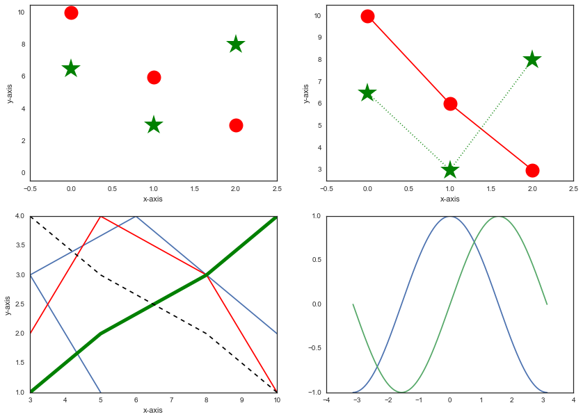

```python
# Subplots Example

plt.figure(figsize=(14, 10))

plt.subplot(2, 2, 1)
plt.plot([10,6,3],'ro',markersize=20)
plt.plot([6.5,3,8],'g*',markersize=30)
# markers = |”.” point|”,” pixel|“o” circle|“v”/“^” triangle_down/up|“<”/“>” triangle_left/right|
plt.xlabel('x-axis')
plt.ylabel('y-axis')
plt.xlim(-0.5,2.5)
plt.ylim(-0.5,10.5)

plt.subplot(2, 2, 2)
plt.plot([10,6,3],'ro-',markersize=20)
plt.plot([6.5,3,8],'g*:',markersize=30)
plt.xlabel('x-axis')
plt.ylabel('y-axis')
plt.xlim(-0.5,2.5)
plt.ylim(2.5,10.5)

plt.subplot(2, 2, 3)
plt.plot([10,6,3,5],[2,4,3,1])
plt.plot([3,5,8,10],[2,4,3,1],'r')
plt.plot([3,5,8,10],[1,2,3,4],'g',linewidth=5)
plt.plot([3,5,8,10],[4,3,2,1],'k--')
plt.xlabel('x-axis')
plt.ylabel('y-axis')

plt.subplot(2, 2, 4)
X = np.linspace(-np.pi, np.pi,256,endpoint=True)
Y1, Y2 = np.cos(X), np.sin(X)
plt.plot(X,Y1)
plt.plot(X,Y2)
```

# 1. ΒΑΣΙΚΕΣ ΜΟΝΟΜΕΤΑΒΛΗΤΕΣ ΣΤΑΤΙΣΤΙΚΕΣ

## 1.1 ΜΕΣΗ ΤΙΜΗ

Η **μέση τιμή** μιας μεταβλητής (λίστας αριθμών) ορίζεται ως το άθροισμα των αριθμών διαιρούμενο με το πλήθος τους.

```python
var1 = [random.choice(range(0,1500,10)) for _ in range(20)]
print var1
```

```
[380, 690, 300, 100, 1350, 40, 1110, 1290, 660, 1090, 820, 940, 170, 940, 30, 1130, 230, 500, 640, 550]
```

```python
name = "var1"
s = sum(var1)
N = len(var1)
mean = s/float(N)
print s
print N
print 'Η μέση τιμή της μεταβλητής %s είναι %.2f' %(name,mean)
```

```
12960
20
Η μέση τιμή της μεταβλητής var1 είναι 648.00
```

```python
name = "wt"
s = sum(wt)
N = len(wt)
mean = s/float(N)
print s
print N
print wt
print 'Η μέση τιμή της μεταβλητής %s είναι %.2f' %(name,mean)
```

```
102.952
32
[2.62, 2.875, 2.32, 3.215, 3.44, 3.46, 3.57, 3.19, 3.15, 3.44, 3.44, 4.07, 3.73, 3.78, 5.25, 5.424, 5.345, 2.2, 1.615, 1.835, 2.465, 3.52, 3.435, 3.84, 3.845, 1.935, 2.14, 1.513, 3.17, 2.77, 3.57, 2.78]
Η μέση τιμή της μεταβλητής wt είναι 3.22
```

```python
def mean(x):
    mean = sum(x)/float(len(x))
    return mean
```

```python
mean(wt)
```

```
3.2172499999999995
```

## 1.2 ΕΝΔΙΑΜΕΣΗ ΤΙΜΗ

Η **ενδιάμεση τιμή** μιας μεταβλητής (λίστας αριθμών) ορίζεται ως ο αριθμός εκείνος εντός ή εκτός της λίστας, που είναι τέτοιος ώστε το πλήθος των αριθμών της λίστας που είναι μικρότεροί του να είναι το ίδιο με το πλήθος των αριθμών της λίστας που είναι μεγαλύτεροί του.

Επομένως, όταν η λίστα έχει περιττό πλήθος αριθμών, τότε η ενδιάμεση τιμή της είναι ένας από τους αριθμούς της λίστας, ενώ όταν η λίστα έχει άρτιο αριθμό, τότε η ενδιάμεση τιμής της είναι ένας αριθμός εκτός λίστας, που ορίζεται ως η μέση τιμή του κάτω ενδιάμεσου και του πάνω ενδιάμεσου της λίστας. Στην περίπτωση αυτή, ο κάτω και ο πάνω ενδιάμεσοςτης λίστας ορίζονται ως οι δυο διαδοχικοί αριθμοί μέσα στη λίστα, που είναι τέτοιοι ώστε το πλήθος των αριθμών της λίστας που είναι μικρότεροι του κάτω ενδιάμεσου να είναι το ίδιο με το πλήθος των αριθμών της λίστας που είναι μεγαλύτεροι του πάνω ενδιάμεσου.

```python
print var1
print len(var1)
print sorted(var1)
print sorted(var1, reverse=True)
```

```
[380, 690, 300, 100, 1350, 40, 1110, 1290, 660, 1090, 820, 940, 170, 940, 30, 1130, 230, 500, 640, 550]
20
[30, 40, 100, 170, 230, 300, 380, 500, 550, 640, 660, 690, 820, 940, 940, 1090, 1110, 1130, 1290, 1350]
[1350, 1290, 1130, 1110, 1090, 940, 940, 820, 690, 660, 640, 550, 500, 380, 300, 230, 170, 100, 40, 30]
```

```python
print len(var1) % 2 == 0
midpoint = len(var1)/2
lowermidpoint = midpoint - 1
uppermidpoint = midpoint
median = (sorted(var1)[lowermidpoint] + sorted(var1)[uppermidpoint])/2.
print midpoint
print sorted(var1)[lowermidpoint], sorted(var1)[uppermidpoint]
print 'Η ενδιάμεση τιμή της μεταβλητής %s είναι %.2f' %(name,median)
```

```
True
10
640 660
Η ενδιάμεση τιμή της μεταβλητής wt είναι 650.00
```

```python
name = "var1o"
var1o = [random.choice(range(0,1500,10)) for _ in range(19)]
print len(var1o) % 2 == 0
midpoint = len(var1o)//2
median = sorted(var1o)[midpoint]
print midpoint
print 'Η ενδιάμεση τιμή της μεταβλητής %s είναι %.2f' %(name,median)
```

```
False
9
Η ενδιάμεση τιμή της μεταβλητής var1o είναι 840.00
```

```python
def median(x):
    N = len(x)
    x.sort()
    if N % 2 == 0: # if N is even
        m1 = N/2
        m2 = (N/2) + 1
        # convert to integer, match position
        m1 = int(m1) - 1
        m2 = int(m2) - 1
        median = (x[m1] + x[m2])/2
    else:
        m = (N+1)/2
        # convert to integer, match position
        m = int(m) - 1
        median = x[m]
    return median
```

```python
print median(qsec), median(wt), median(var1), median(var1o)
print qsec
```

```
17.71 3.325 650 840
[14.5, 14.6, 15.41, 15.5, 15.84, 16.46, 16.7, 16.87, 16.9, 17.02, 17.02, 17.05, 17.3, 17.4, 17.42, 17.6, 17.82, 17.98, 18.0, 18.3, 18.52, 18.6, 18.61, 18.9, 18.9, 19.44, 19.47, 19.9, 20.0, 20.01, 20.22, 22.9]
```

## 1.3 ΕΚΑΤΟΣΤΗΜΟΡΙΑ

Το **p-εκατοστημόριο** μιας μεταβλητής (λίστας αριθμών) είναι εκείνος ο αριθμός, που είναι τέτοιος ώστε, όταν οι όροι της λίστας διαταχθούν σε αύξουσα σειρά, το p% των στοιχείων της λίστας να είναι μικρότερό του και το (100-p)% των στοιχείων της λίστας να είναι μεγαλύτερό του.

Προφανώς, όταν το πλήθος των αριθμών της λίστας είναι περιττό, το 0.5-εκατοστημόριο είναι ακριβώς η ενδιάμεση τιμή.

```python
name = "var1o"
print var1o
print sorted(var1o)
plist = [0.10, 0.25, 0.50, 0.75, 0.90]
for p in plist:
    p_index = int(p * len(var1o))
    print 'Το %.2f-εκατοστημόριο της μεταβλητής %s είναι %d' %(p,name,sorted(var1o)[p_index])
```

```
[0, 20, 50, 140, 390, 560, 660, 720, 730, 840, 880, 880, 900, 960, 1000, 1020, 1260, 1380, 1410]
[0, 20, 50, 140, 390, 560, 660, 720, 730, 840, 880, 880, 900, 960, 1000, 1020, 1260, 1380, 1410]
Το 0.10-εκατοστημόριο της μεταβλητής var1o είναι 20
Το 0.25-εκατοστημόριο της μεταβλητής var1o είναι 390
Το 0.50-εκατοστημόριο της μεταβλητής var1o είναι 840
Το 0.75-εκατοστημόριο της μεταβλητής var1o είναι 1000
Το 0.90-εκατοστημόριο της μεταβλητής var1o είναι 1380
```

```python
def quantile(x, p):
    """returns the pth-percentile value in x"""
    p_index = int(p * len(x))
    return sorted(x)[p_index]
```

```python
print quantile(var1o,0.75), quantile(wt,0.15), quantile(qsec,0.60)
```

```
1000 2.14 18.3
```

## 1.4 ΕΠΙΚΡΑΤΕΣΤΕΡΕΣ ΤΙΜΕΣ

Οι **επικρατέστερες τιμές** μιας μεταβλητής (λίστας αριθμών) είναι το σύνολο εκείνων των όρων (αριθμών) μέσα στη λίστα που εμφανίζονται τις περισσότερες φορές.

```python
name = "var1"
var1[1] = 680
print var1
counts = Counter(var1)
print type(counts), counts
max_count = max(counts.values())
print max_count
mode = [x_i for x_i, count in counts.iteritems() if count == max_count]
print 'Η λίστα των επικρατέστερων τιμών της μεταβλητής', name, 'είναι', mode
```

```
[30, 680, 100, 170, 230, 300, 380, 500, 550, 640, 660, 690, 820, 940, 940, 1090, 1110, 1130, 1290, 1350]
<class 'collections.Counter'> Counter({940: 2, 640: 1, 1090: 1, 100: 1, 550: 1, 230: 1, 680: 1, 170: 1, 300: 1, 1350: 1, 690: 1, 500: 1, 1110: 1, 820: 1, 660: 1, 1290: 1, 380: 1, 1130: 1, 30: 1})
2
Η λίστα των επικρατέστερων τιμών της μεταβλητής var1 είναι [940]
```

```python
name = "am"
counts = Counter(am)
print type(counts), counts
max_count = max(counts.values())
print max_count
mode = [x_i for x_i, count in counts.iteritems() if count == max_count]
print 'Η λίστα των επικρατέστερων τιμών της μεταβλητής', name, 'είναι', mode
```

```
<class 'collections.Counter'> Counter({0: 19, 1: 13})
19
Η λίστα των επικρατέστερων τιμών της μεταβλητής am είναι [0]
```

```python
name = "var2"
var2 = [random.choice(range(3)) for _ in range(5)]
print var2
counts = Counter(var2)
print type(counts), counts
max_count = max(counts.values())
print max_count
mode = [x_i for x_i, count in counts.iteritems() if count == max_count]
print 'Η λίστα των επικρατέστερων τιμών της μεταβλητής', name, 'είναι', mode
```

```
[0, 1, 1, 0, 1]
<class 'collections.Counter'> Counter({1: 3, 0: 2})
3
Η λίστα των επικρατέστερων τιμών της μεταβλητής var2 είναι [1]
```

```python
def mode(x):
    counts = Counter(x)
    max_count = max(counts.values())
    return [x_i for x_i, count in counts.iteritems() if count == max_count]
```

```python
print mode(qsec), mode(hp)
```

```
[17.02, 18.9] [175, 180, 110]
```

## 1.5 ΕΥΡΟΣ, ΜΕΓΑΛΥΤΕΡΕΣ-ΜΙΚΡΟΤΕΡΕΣ ΤΙΜΕΣ

```python
name = "var1"
var1 = [random.choice(range(0,1500,10)) for _ in range(20)]
print var1
print 'Η μεγαλύτερη τιμή της μεταβλητής', name, 'είναι', max(var1)
print 'Η μικρότερη τιμή της μεταβλητής', name, 'είναι', min(var1)
print 'Το εύρος της μεταβλητής', name, 'είναι', max(var1) - min(var1)
```

```
[430, 860, 130, 820, 1210, 1190, 1100, 960, 210, 230, 520, 1030, 1400, 1440, 790, 1430, 660, 390, 770, 1340]
Η μεγαλύτερη τιμή της μεταβλητής var1 είναι 1440
Η μικρότερη τιμή της μεταβλητής var1 είναι 130
Το εύρος της μεταβλητής var1 είναι 1310
```

```python
def data_mxrange(x):
    return max(x), min(x), max(x) - min(x)
```

```python
print 'Η μεταβλητή', name, 'έχει:'
print 'max =', data_mxrange(var1)[0]
print 'min =', data_mxrange(var1)[1]
print 'range =', data_mxrange(var1)[2]
```

```
Η μεταβλητή var1 έχει:
max = 1440
min = 130
range = 1310
```

```python
name = 'qsec'
print 'Η μεταβλητή', name, 'έχει:'
print 'max =', data_mxrange(qsec)[0]
print 'min =', data_mxrange(qsec)[1]
print 'range =', data_mxrange(qsec)[2]
```

```
Η μεταβλητή qsec έχει:
max = 22.9
min = 14.5
range = 8.4
```

## 1.6 ΔΙΑΚΥΜΑΝΣΗ ΚΑΙ ΤΥΠΙΚΗ ΑΠΟΚΛΙΣΗ

Η **διακύμανση** μιας μεταβλητής (λίστας αριθμών) ορίζεται ως το άθροισμα των τετραγώνων των διαφορών των στοιχείων της λίστας από τη μέση τους τιμή διαιρούμενο με το πλήθος τους. Η **τυπική απόκλιση** είναι η τετραγωνική ρίζα της διακύμανσης.

Η **δειγματική διακύμανση** (και αντίστοιχα η **δειγματική τυπική απόκλιση**) ορίζεται όπως πριν αλλά διαιρώντας με n - 1, όπου n είναι το πλήθος των όρων της μεταβλητής (λίστας).

```python
name = 'var1'
var1 = [random.choice(range(0,1500,10)) for _ in range(20)]
print var1
print mean(var1)
sdiff = [(xi - mean(var1))**2 for xi in var1]
variance_var1 = sum(sdiff)/float(len(var1))
stdev_var1 = math.sqrt(variance_var1)
svariance_var1 = sum(sdiff)/float(len(var1)-1)
sstdev_var1 = math.sqrt(svariance_var1)
print 'Η διακύμανη και η τυπική απόκλιση της μεταβλητής %s είναι %.2f, %.2f' %(name,variance_var1,stdev_var1)
print 'Η δειγματική διακύμανη και η δειγματική τυπική απόκλιση της μεταβλητής %s είναι %.2f, %.2f' %(name,svariance_var1,sstdev_var1)
```

```
[80, 1380, 150, 100, 460, 1220, 910, 600, 370, 1330, 750, 900, 760, 1260, 180, 450, 890, 170, 670, 1040]
683.5
Η διακύμανη και η τυπική απόκλιση της μεταβλητής var1 είναι 175892.75, 419.40
Η δειγματική διακύμανη και η δειγματική τυπική απόκλιση της μεταβλητής var1 είναι 185150.26, 430.29
```

```python
def variance(x):
    return sum([(xi - mean(x))**2 for xi in x])/float(len(x))
def svariance(x):
    return sum([(xi - mean(x))**2 for xi in x])/float(len(x)-1)
```

```python
print variance(var1), svariance(var1)
```

```
175892.75 185150.263158
```

```python
print variance(cyl), svariance(cyl)
print math.sqrt(variance(cyl)), math.sqrt(svariance(cyl))
```

```
3.08984375 3.18951612903
1.7577951388 1.78592164695
```

```python
print cyl
print len(cyl), mean(cyl), max(cyl), min(cyl)
```

```
[6, 6, 4, 6, 8, 6, 8, 4, 4, 6, 6, 8, 8, 8, 8, 8, 8, 4, 4, 4, 4, 8, 8, 8, 8, 4, 4, 4, 8, 6, 8, 4]
32 6.1875 8 4
```

```python
mtcars = pd.read_csv("https://vincentarelbundock.github.io/Rdatasets/csv/datasets/mtcars.csv")
mtcars['cyl'].std()
```

```
1.7859216469465444
```

## 1.7 ΣΥΓΚΕΝΤΡΩΤΙΚΕΣ ΜΟΝΟΜΕΤΑΒΛΗΤΕΣ ΣΤΑΤΙΣΤΙΚΕΣ

```python
def desc(x):
    a1 = ['count','mean','std','min','25%','50%','75%','max']
    a2 = [len(x),mean(x),math.sqrt(svariance(x)),min(x),quantile(x, 0.25),quantile(x, 0.50),
          quantile(x, 0.75),max(x)]
#     count = len(x)
#     mean = mean(x)
#     std = math.sqrt(svariance(x))
#     minimum = min(x)
#     pc25 = quantile(x, 0.25)
#     pc50 = quantile(x, 0.50)
#     pc75 = quantile(x, 0.75)
#     maximum = max(x)
    return a1, a2
```

```python
x = var1
for i in range(len(desc(x)[0])):
    print desc(x)[0][i], desc(x)[1][i]
```

```
count 20
mean 683.5
std 430.29090527
min 80
25% 370
50% 750
75% 1040
max 1380
```

```python
x = cyl
for i in range(len(desc(x)[0])):
    print desc(x)[0][i], desc(x)[1][i]

mtcars['cyl'].describe()
```

```
count 32
mean 6.1875
std 1.78592164695
min 4
25% 4
50% 6
75% 8
max 8
```

```
count    32.000000
mean      6.187500
std       1.785922
min       4.000000
25%       4.000000
50%       6.000000
75%       8.000000
max       8.000000
Name: cyl, dtype: float64
```

# 2. ΣΧΕΔΙΑΓΡΑΜΜΑΤΑ ΜΟΝΟΜΕΤΑΒΛΗΤΩΝ ΣΤΑΤΙΣΤΙΚΩΝ

## 2.1 Απλά Σχεδιαγράμματα

```
[1080, 900, 790, 1340, 440, 680, 550, 180, 1060, 940, 10, 520, 1480, 960, 380, 280, 1280, 60, 630, 170]
```

```
 <a list of 20 Text xticklabel objects>)
```

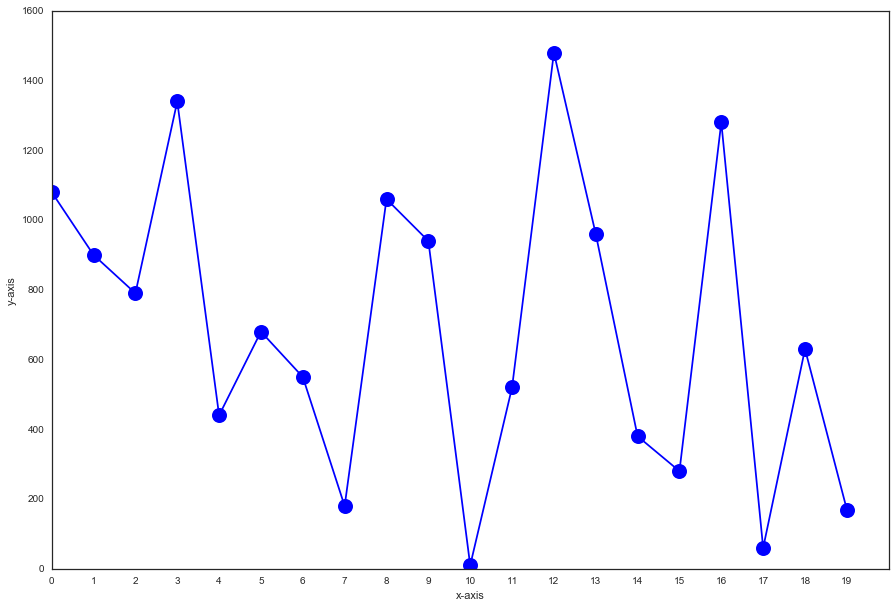

```python
var1 = [random.choice(range(0,1500,10)) for _ in range(20)]
print var1
X = range(len(var1))
Y = var1
plt.figure(figsize=(15, 10))
plt.plot(X,Y,'bo-',markersize=15)
plt.xlabel('x-axis')
plt.ylabel('y-axis')
plt.xticks(X)
```

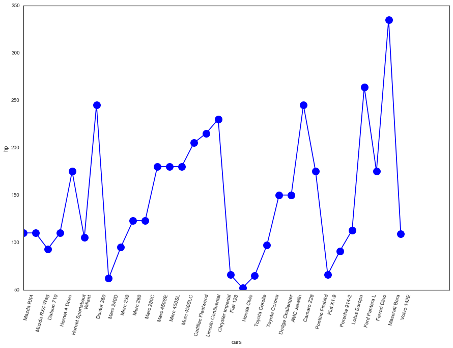

```python
X = range(len(cars))
Y = hp
plt.figure(figsize=(15, 10))
plt.plot(X,Y,'bo-',markersize=15)
plt.xticks(X,cars,rotation=75,ha='left')
plt.xlabel('cars')
plt.ylabel('hp')
```

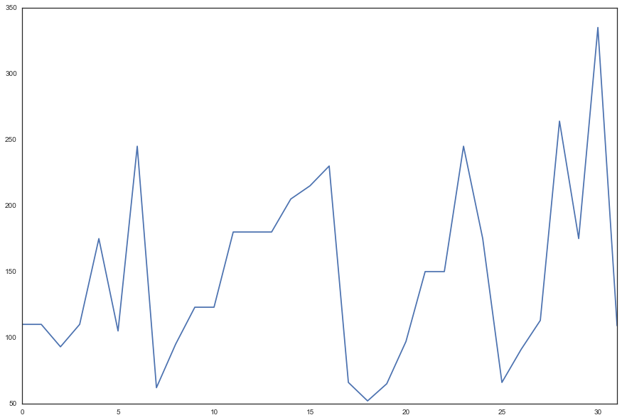

```python
plt.figure(figsize=(15, 10))
mtcars['hp'].plot()
```

## 2.2 ΡΑΒΔΟΓΡΑΜΜΑΤΑ

```python
def barplot(data,offset):
    n = len(data)
    X = range(n)
    Y = data
    plt.figure(figsize=(15, 10))
    plt.bar(X, Y, facecolor='#9999ff', edgecolor='black')
    for a,b in zip(X, Y):
        plt.text(a + 0.4, b + 0.05, '%i' % b, ha='center', va='bottom')
    plt.xlim(-.5, n)
    plt.ylim(0, max(data) + offset)
    plt.xticks(X)
```

```
[770, 660, 310, 210, 1180, 810, 1040, 90, 1080, 1140, 360, 800, 310, 300, 980, 510, 1360, 1450, 440, 1230]
```

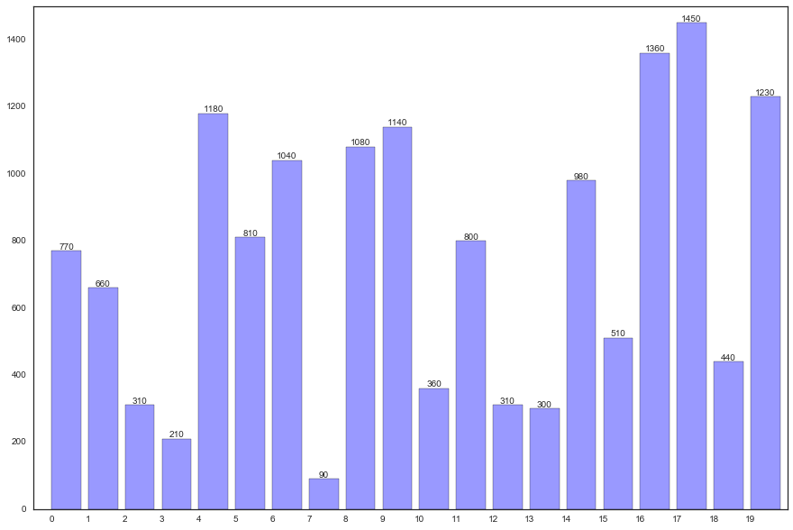

```python
var1 = [random.choice(range(0,1500,10)) for _ in range(20)]
print var1
barplot(var1,50)
```

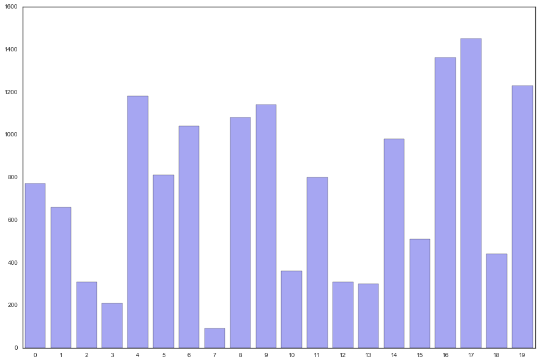

```python
plt.figure(figsize=(15, 10))
sns.barplot(range(len(var1)),var1,color='#9999ff')
# sns.barplot(range(len(var1)),var1)
```

```python
def barplot(labels,data,offset):
    n = len(labels)
    X = range(n)
    Y = data
    plt.figure(figsize=(15, 10))
    plt.bar(X, Y, facecolor='#9999ff', edgecolor='black')
    for a,b in zip(X, Y):
        plt.text(a + 0.4, b + 0.05, '%i' % b, ha='center', va='bottom')
    plt.xlim(-.5, n)
    plt.xticks(X,labels,rotation=75,ha='left')
    plt.ylim(0, max(data) + offset)
```

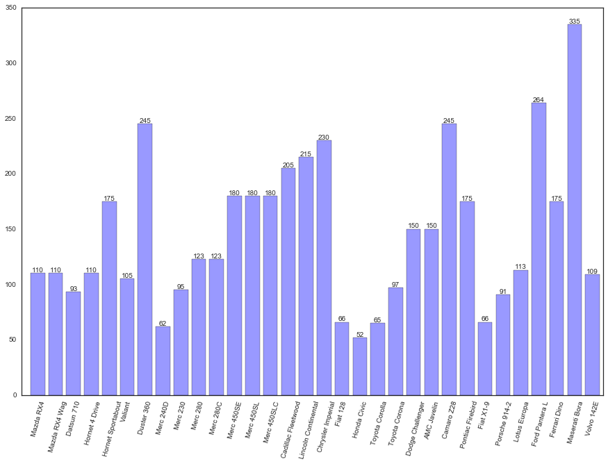

```python
barplot(cars,hp,15)
```

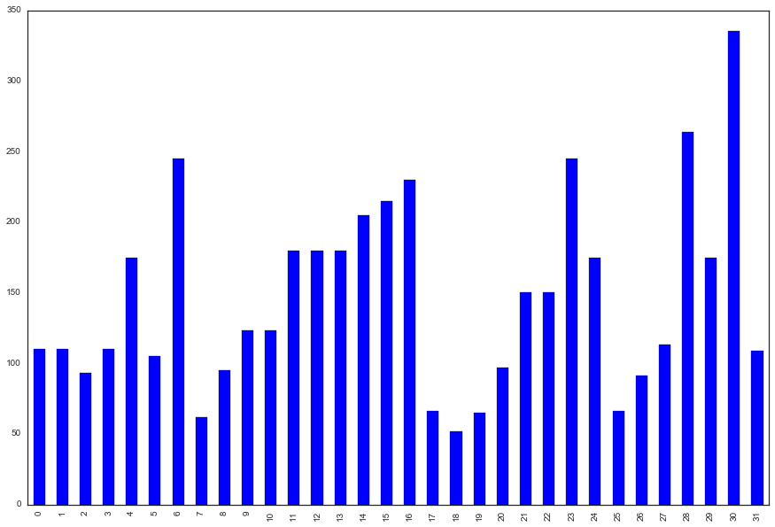

```python
plt.figure(figsize=(15, 10))
mtcars['hp'].plot.bar()
```

## 2.3 ΚΥΚΛΙΚΑ ΔΙΑΓΡΑΜΜΑΤΑ

[figure not shown]

```python
labels = range(len(var1))
sizes = var1

# colors = [(0,0,1,i/float(len(labels))) for i in range(len(labels))] #blue
# colors = [(1,0,0,i/float(len(labels))) for i in range(len(labels))] #red
# colors = [(0,0,0,i/float(len(labels))) for i in range(len(labels))] #black
colors=cm.Set1(np.arange(len(labels))/float(len(labels)))

plt.figure(figsize=(10, 10))
plt.pie(sizes, labels=labels, colors=colors,labeldistance=1.05)
# plt.pie(sizes, labels=labels, colors=colors,autopct='%1.0f%%',pctdistance=0.8,labeldistance=1.05)
plt.title('Pie Plot of var1',loc='left',fontsize=20)
plt.axis('equal')
plt.xticks(())
plt.yticks()
plt.show()
```

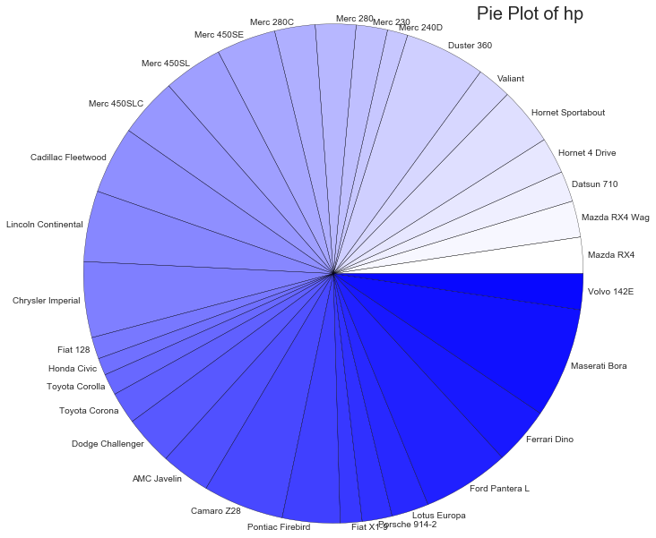

```python
labels = cars
sizes = hp

colors = [(0,0,1,i/float(len(labels))) for i in range(len(labels))] #blue
# colors = [(1,0,0,i/float(len(labels))) for i in range(len(labels))] #red
# colors = [(0,0,0,i/float(len(labels))) for i in range(len(labels))] #black
# colors=cm.Set1(np.arange(len(labels))/float(len(labels)))

plt.figure(figsize=(10, 10))
plt.pie(sizes, labels=labels, colors=colors,labeldistance=1.02)
# plt.pie(sizes, labels=labels, colors=colors,autopct='%1.0f%%',pctdistance=0.8,labeldistance=1.02)
plt.title('Pie Plot of hp',loc='right',fontsize=20)
plt.axis('equal')
plt.xticks(())
plt.yticks()
plt.show()
```

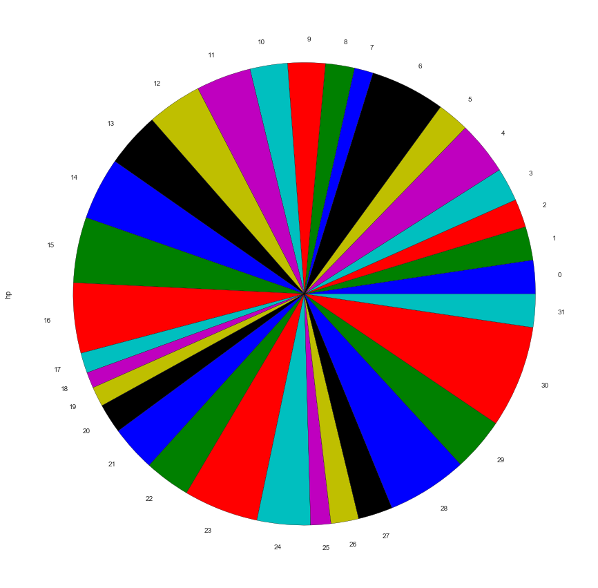

```python
plt.figure(figsize=(15, 15))
mtcars['hp'].plot.pie()
```

# 2.4 ΙΣΤΟΓΡΑΜΜΑΤΑ

```python
def histogram(data,xname,yname,bins,xticks=True):   #offset,
    data_counts = Counter(data)
    n = max(data_counts.keys())
    plt.figure(figsize=(15, 10))
    plt.hist(data, bins=bins, facecolor='#9999ff', edgecolor='black')
    stitl="Histogram of %s Counts" %xname
    plt.title(stitl)
    if xticks:
        plt.xticks(data,rotation='vertical',ha='left')
    xtitl="# of %s" %xname
    ytitl="# of %s" %yname
    plt.xlabel(xtitl)
    plt.ylabel(ytitl)
```

```
[770, 220, 860, 180, 710, 660, 100, 570, 430, 1210, 520, 1120, 660, 530, 800, 820, 1480, 1360, 890, 800]
Counter({800: 2, 660: 2, 1120: 1, 770: 1, 100: 1, 710: 1, 520: 1, 220: 1, 890: 1, 430: 1, 1360: 1, 1480: 1, 530: 1, 820: 1, 180: 1, 570: 1, 860: 1, 1210: 1})
```

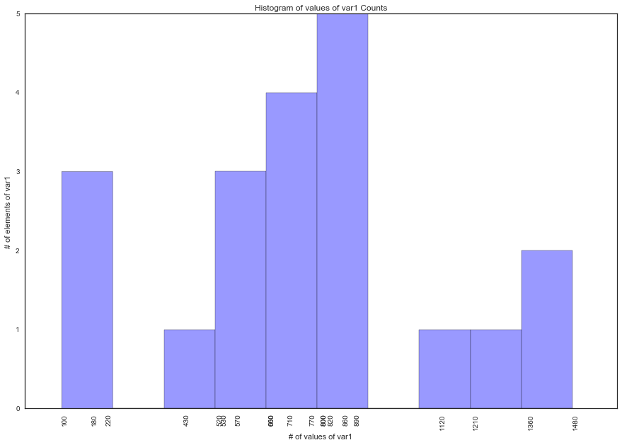

```python
var1 = [random.choice(range(0,1500,10)) for _ in range(20)]
print var1
print Counter(var1)
# plt.figure(figsize=(15, 10))
histogram(var1,'values of var1','elements of var1',10,xticks=True)
```

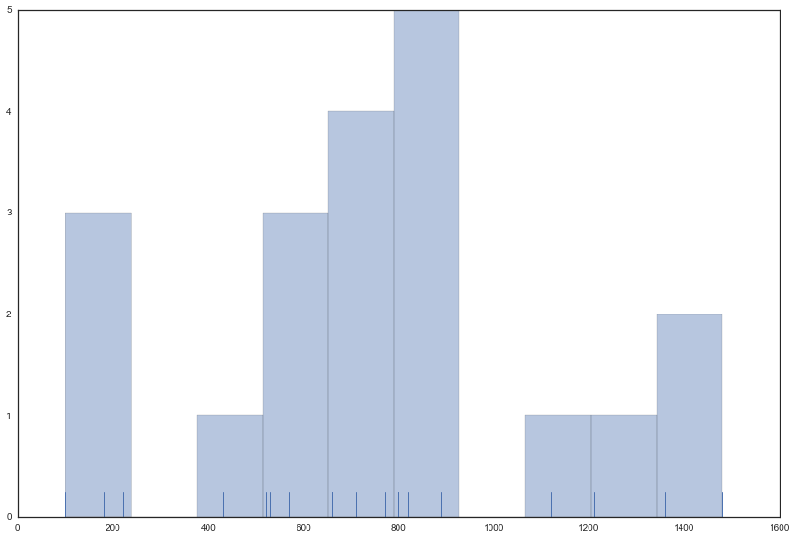

```python
plt.figure(figsize=(15, 10))
sns.distplot(var1, bins=10, kde=False, rug=True)
```

```
[110, 110, 93, 110, 175, 105, 245, 62, 95, 123, 123, 180, 180, 180, 205, 215, 230, 66, 52, 65, 97, 150, 150, 245, 175, 66, 91, 113, 264, 175, 335, 109]
Counter({175: 3, 180: 3, 110: 3, 150: 2, 66: 2, 245: 2, 123: 2, 264: 1, 52: 1, 62: 1, 65: 1, 205: 1, 335: 1, 215: 1, 91: 1, 93: 1, 95: 1, 97: 1, 230: 1, 105: 1, 109: 1, 113: 1})
```

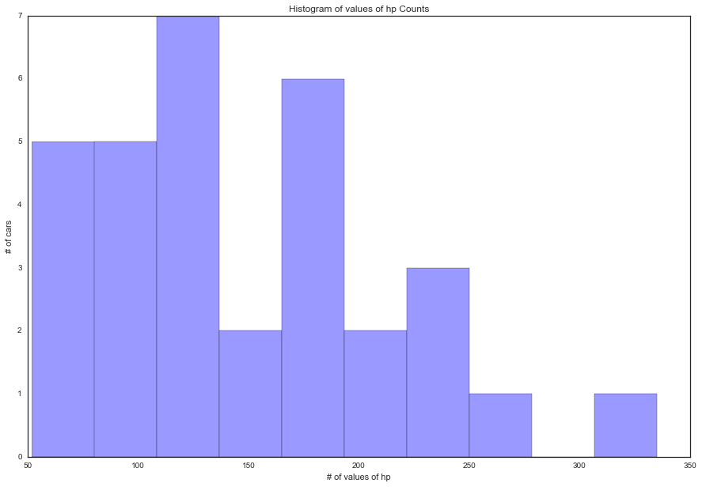

```python
print hp
print Counter(hp)
plt.figure(figsize=(15, 10))
histogram(hp,'values of hp','cars',10,xticks=False)
```

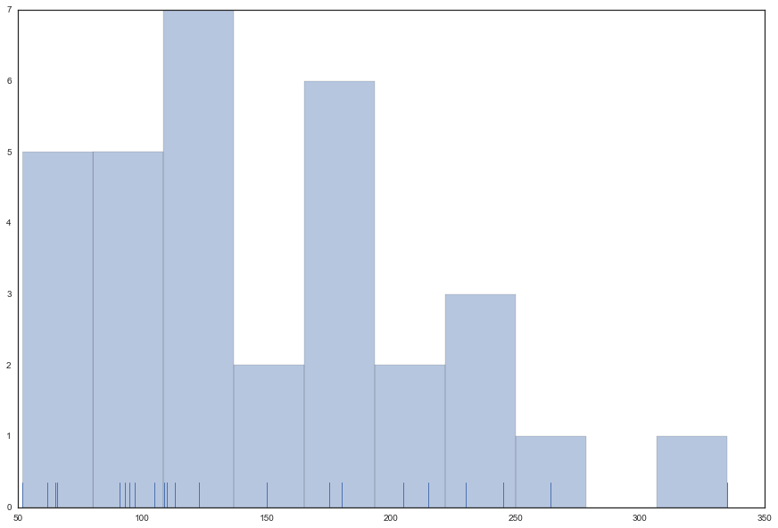

```python
plt.figure(figsize=(15, 10))
sns.distplot(hp, bins=10, kde=False, rug=True)
```

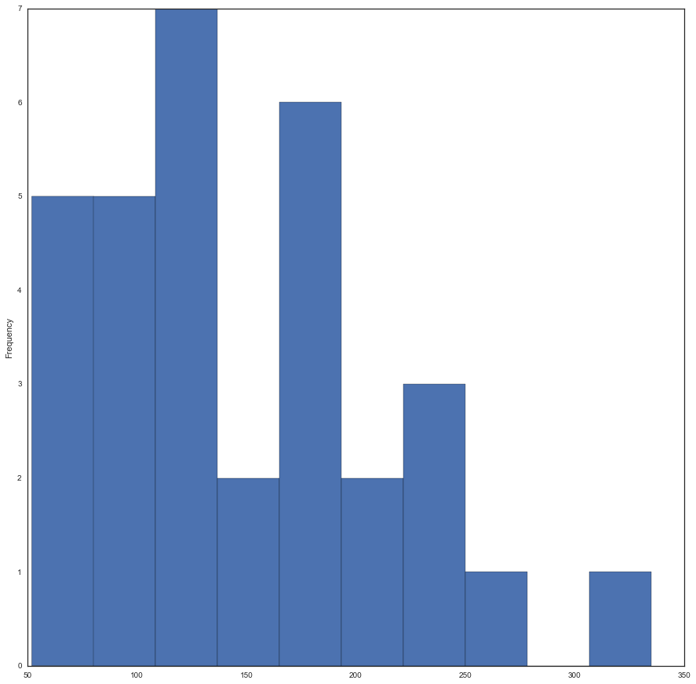

```python
plt.figure(figsize=(15, 15))
mtcars['hp'].plot.hist()
```

# 2.5 ΘΗΚΟΓΡΑΜΜΑΤΑ

```
[700, 600, 990, 150, 320, 1090, 460, 1160, 1030, 1100, 500, 960, 1020, 240, 940, 600, 490, 450, 330, 240]
```

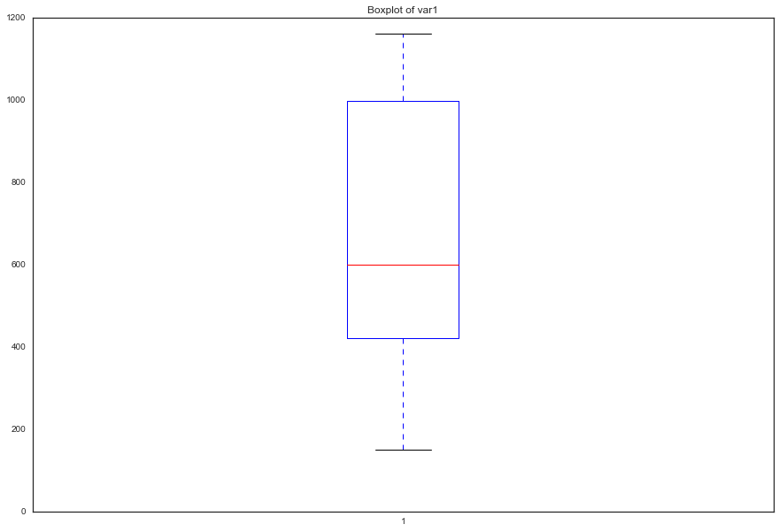

```python
name = 'var1'
var1 = [random.choice(range(0,1500,10)) for _ in range(20)]
print var1
plt.figure(figsize=(15, 10))
plt.boxplot(var1)
stitl="Boxplot of %s" %name
plt.title(stitl)
```

[figure not shown]

```python
name1 = 'hp'
name2 = 'disp'
plt.figure(figsize=(12,8))
plt.subplot(1, 2, 1)
plt.boxplot(disp)
stitl="Boxplot of %s" %name1
plt.title(stitl)
plt.subplot(1, 2, 2)
plt.boxplot(hp)
stitl="Boxplot of %s" %name2
plt.title(stitl)
```

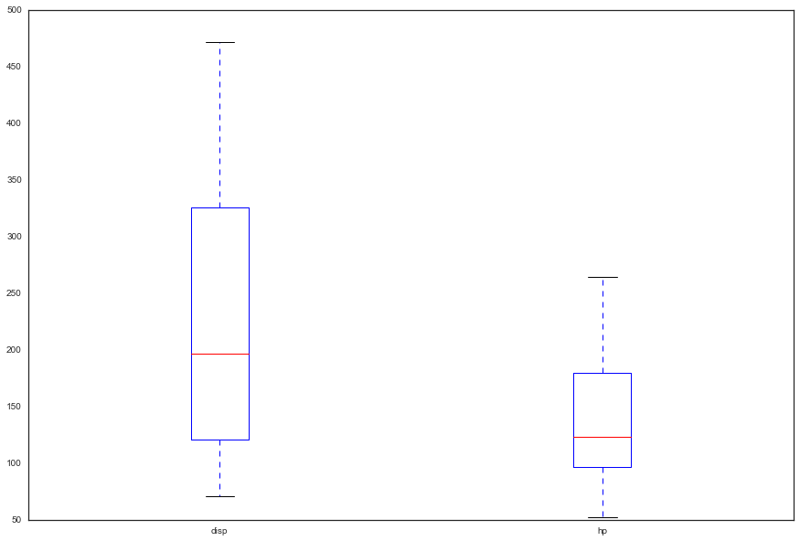

```python
mtcars[['disp','hp']].plot.box(figsize=(15, 10))
```

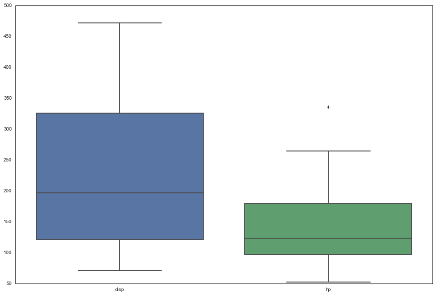

```python
plt.figure(figsize=(15, 10))
sns.boxplot(mtcars[['disp','hp']],orient='v')
```